# Predicting Customer Churn for a Telecommunications Company

by P.Chamisa

## Introduction

Telecommunications companies rely heavily on customer retention to maintain their profitability. Losing customers to competitors can result in significant revenue loss, especially considering the high acquisition costs associated with attracting new customers. Therefore, it is crucial for these companies to identify customers who are at risk of churning and take proactive measures to retain them.

In this project, we will use machine learning to analyze customer data and predict which customers are likely to churn, allowing the company to take preventative measures. Specifically, we will be working with a dataset from a telecommunications company containing information on customer demographics, account information, and service usage. Our goal is to build a model that can accurately predict whether a customer will churn or not.

## Data Exploration and Preparation

First, we'll load the dataset and perform some initial exploratory data analysis (EDA) to better understand the data.

```python
#Importing libraries
import pandas as pd
import numpy as np
import matplotlib.pyplot as plt
import seaborn as sns
from PIL import Image
import warnings
warnings.filterwarnings("ignore")
import os
%matplotlib inline
```

```python
# Load the dataset
df = pd.read_csv('churn-bigml-80.csv')
df_test = pd.read_csv('churn-bigml-20.csv')

# Examine the first few rows
df.head()
```

|  | State | Account length | Area code | International plan | Voice mail plan | Number vmail messages | Total day minutes | Total day calls | Total day charge | Total eve minutes | Total eve calls | Total eve charge | Total night minutes | Total night calls | Total night charge | Total intl minutes | Total intl calls | Total intl charge | Customer service calls | Churn |
| --- | --- | --- | --- | --- | --- | --- | --- | --- | --- | --- | --- | --- | --- | --- | --- | --- | --- | --- | --- | --- |
| 0 | KS | 128 | 415 | No | Yes | 25 | 265.1 | 110 | 45.07 | 197.4 | 99 | 16.78 | 244.7 | 91 | 11.01 | 10.0 | 3 | 2.70 | 1 | False |
| 1 | OH | 107 | 415 | No | Yes | 26 | 161.6 | 123 | 27.47 | 195.5 | 103 | 16.62 | 254.4 | 103 | 11.45 | 13.7 | 3 | 3.70 | 1 | False |
| 2 | NJ | 137 | 415 | No | No | 0 | 243.4 | 114 | 41.38 | 121.2 | 110 | 10.30 | 162.6 | 104 | 7.32 | 12.2 | 5 | 3.29 | 0 | False |
| 3 | OH | 84 | 408 | Yes | No | 0 | 299.4 | 71 | 50.90 | 61.9 | 88 | 5.26 | 196.9 | 89 | 8.86 | 6.6 | 7 | 1.78 | 2 | False |
| 4 | OK | 75 | 415 | Yes | No | 0 | 166.7 | 113 | 28.34 | 148.3 | 122 | 12.61 | 186.9 | 121 | 8.41 | 10.1 | 3 | 2.73 | 3 | False |

```python
def dataoveriew(df, message):
    print(f'{message}:\n')
    print("Rows:", df.shape[0])
    print("\nNumber of features:", df.shape[1])
    print("\nFeatures:")
    print(df.columns.tolist())
    print("\nMissing values:", df.isnull().sum().values.sum())
    print("\nUnique values:")
    print(df.nunique())
```

```python
dataoveriew(df, 'Overiew of the training dataset')
```

```
Overiew of the training dataset:

Rows: 2666

Number of features: 20

Features:
['State', 'Account length', 'Area code', 'International plan', 'Voice mail plan', 'Number vmail messages', 'Total day minutes', 'Total day calls', 'Total day charge', 'Total eve minutes', 'Total eve calls', 'Total eve charge', 'Total night minutes', 'Total night calls', 'Total night charge', 'Total …

Missing values: 0

Unique values:
State                       51
Account length             205
Area code                    3
International plan           2
Voice mail plan              2
Number vmail messages       42
Total day minutes         1489
Total day calls            115
Total day charge          1489
Total eve minutes         1442
Total eve calls            120
Total eve charge          1301
Total night minutes       1444
Total night calls          118
Total night charge         885
Total intl minutes         158
Total intl calls            21
Total intl charge          158
Customer service calls      10
Churn                        2
dtype: int64
```

```python
dataoveriew(df_test, 'Overiew of the training dataset')
```

```
Overiew of the training dataset:

Rows: 667

Number of features: 20

Features:
['State', 'Account length', 'Area code', 'International plan', 'Voice mail plan', 'Number vmail messages', 'Total day minutes', 'Total day calls', 'Total day charge', 'Total eve minutes', 'Total eve calls', 'Total eve charge', 'Total night minutes', 'Total night calls', 'Total night charge', 'Total …

Missing values: 0

Unique values:
State                      51
Account length            179
Area code                   3
International plan          2
Voice mail plan             2
Number vmail messages      37
Total day minutes         562
Total day calls           100
Total day charge          562
Total eve minutes         557
Total eve calls            94
Total eve charge          528
Total night minutes       568
Total night calls          96
Total night charge        453
Total intl minutes        132
Total intl calls           17
Total intl charge         132
Customer service calls      9
Churn                       2
dtype: int64
```

```python
df.Churn.value_counts(1)
```

[output not shown]

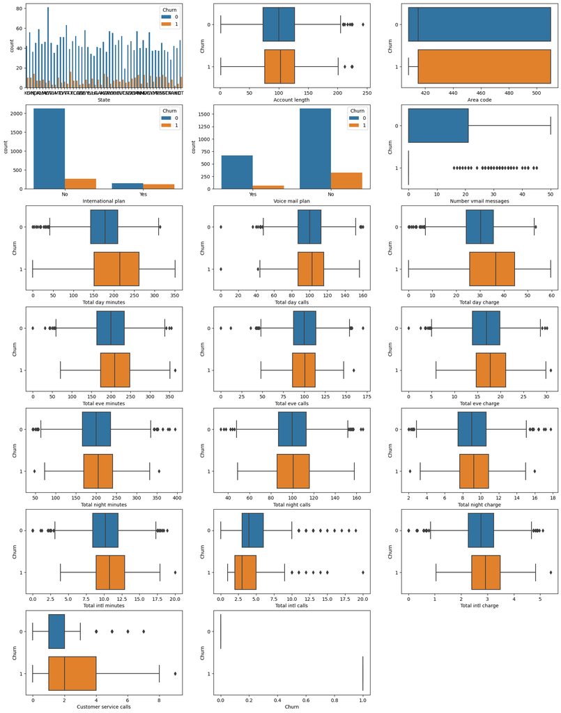

```python
# outlier detection using boxplot
cols = df.columns.tolist()
df.Churn *= 1

plt.figure(figsize=(20, 30))

for i, variable in enumerate(df.columns.tolist()):
    plt.subplot(8, 3, i + 1)
    if df.dtypes[variable]=='object':
        sns.countplot(data=df, x=variable, hue='Churn')
    else:
        sns.boxplot(data=df, x=variable, y=df['Churn'].astype('str'))

plt.show()
```

```python
# ref: https://www.kaggle.com/code/ahsan81/telecom-churn-98-acc-eda-xgb
# defining a function for getting percentages
def crosstab_function(df, var):
    tab = pd.DataFrame(pd.crosstab(df[var], df["Churn"], margins=True)).reset_index()
    tab['Percentage'] = tab[1] / tab['All'] * 100
    tab.columns = [var, 'Churn_NO', 'Churn_YES', 'Total', 'Churn Percentage']
    return tab
```

|  | International plan | Churn_NO | Churn_YES | Total | Churn Percentage |
| --- | --- | --- | --- | --- | --- |
| 0 | No | 2126 | 270 | 2396 | 11.268781 |
| 1 | Yes | 152 | 118 | 270 | 43.703704 |
| 2 | All | 2278 | 388 | 2666 | 14.553638 |

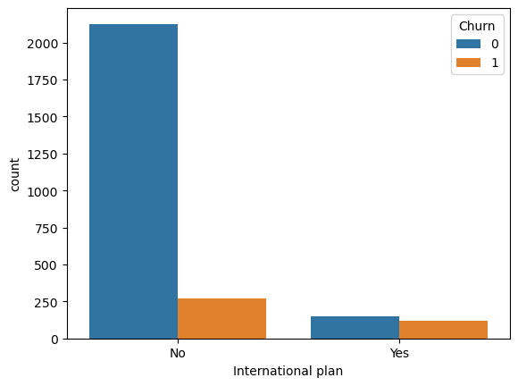

```python
sns.countplot(data=df, x=df['International plan'], hue='Churn');
crosstab_function(df,'International plan')
```

Customers who subscribe to an international plan churn more than those who do not. This is shown by a churn percentage of 43% among those who subscribe to an International plan as compared to 11% of those who do not.

|  | Voice mail plan | Churn_NO | Churn_YES | Total | Churn Percentage |
| --- | --- | --- | --- | --- | --- |
| 0 | No | 1610 | 323 | 1933 | 16.709778 |
| 1 | Yes | 668 | 65 | 733 | 8.867667 |
| 2 | All | 2278 | 388 | 2666 | 14.553638 |

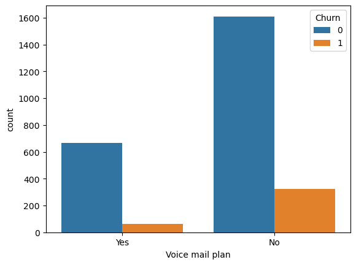

```python
sns.countplot(data=df, x=df['Voice mail plan'], hue='Churn');
crosstab_function(df,'Voice mail plan')
```

|  | Customer service calls | Churn_NO | Churn_YES | Total | Churn Percentage |
| --- | --- | --- | --- | --- | --- |
| 0 | 0 | 476 | 79 | 555 | 14.234234 |
| 1 | 1 | 846 | 99 | 945 | 10.476190 |
| 2 | 2 | 546 | 62 | 608 | 10.197368 |
| 3 | 3 | 311 | 37 | 348 | 10.632184 |
| 4 | 4 | 69 | 64 | 133 | 48.120301 |
| 5 | 5 | 20 | 29 | 49 | 59.183673 |
| 6 | 6 | 7 | 10 | 17 | 58.823529 |
| 7 | 7 | 3 | 5 | 8 | 62.500000 |
| 8 | 8 | 0 | 1 | 1 | 100.000000 |
| 9 | 9 | 0 | 2 | 2 | 100.000000 |
| 10 | All | 2278 | 388 | 2666 | 14.553638 |

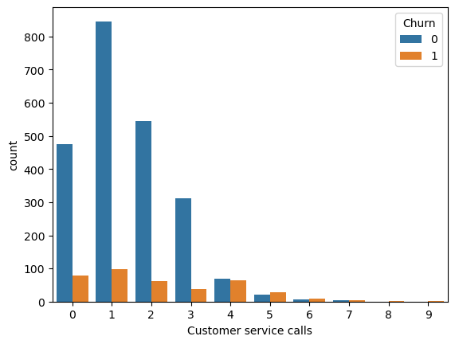

```python
sns.countplot(data=df, x=df['Customer service calls'], hue=df['Churn']);
crosstab_function(df,'Customer service calls')
```

[figure not shown]

```python
plt.figure(figsize=(12, 5))
sns.histplot(data=df, x='Account_length', hue='Churn', bins=30, kde=True)
plt.xlabel('Account_length (days)', fontsize=12)
plt.ylabel('Count', fontsize=12)
plt.title('Distribution of Account_length by Churn Status', fontsize=14)
plt.legend(labels=['Not Churn', 'Churn'])
plt.show()
```

### Data Preprocessing

Next, we'll perform some data cleaning and feature engineering to prepare the data for modeling.

```python
df.dtypes
```

```
State                      object
Account length              int64
Area code                   int64
International plan         object
Voice mail plan            object
Number vmail messages       int64
Total day minutes         float64
Total day calls             int64
Total day charge          float64
Total eve minutes         float64
Total eve calls             int64
Total eve charge          float64
Total night minutes       float64
Total night calls           int64
Total night charge        float64
Total intl minutes        float64
Total intl calls            int64
Total intl charge         float64
Customer service calls      int64
Churn                       int64
dtype: object
```

```python
# Replacing all the whitespace with under score(_) in all column names
df.columns = df.columns.str.replace(' ', '_')
```

```python
# Confirming changes
df.dtypes
```

```
State                      object
Account_length              int64
Area_code                   int64
International_plan         object
Voice_mail_plan            object
Number_vmail_messages       int64
Total_day_minutes         float64
Total_day_calls             int64
Total_day_charge          float64
Total_eve_minutes         float64
Total_eve_calls             int64
Total_eve_charge          float64
Total_night_minutes       float64
Total_night_calls           int64
Total_night_charge        float64
Total_intl_minutes        float64
Total_intl_calls            int64
Total_intl_charge         float64
Customer_service_calls      int64
Churn                       int64
dtype: object
```

## Model Building and Evaluation

Now that we have a better understanding of the data, we'll build several machine learning models to predict customer churn. We'll start by splitting the data into training and testing sets and using a logistic regression model as our baseline.

```python
import xgboost as xgb
from sklearn.model_selection import train_test_split
from sklearn.compose import ColumnTransformer
from sklearn.preprocessing import OneHotEncoder
from sklearn.linear_model import LogisticRegression
from sklearn.metrics import accuracy_score, precision_score, recall_score, f1_score
from sklearn.ensemble import RandomForestClassifier
from sklearn.svm import SVC
from sklearn.ensemble import GradientBoostingClassifier



# Define the features and target variables
X = df.drop('Churn', axis=1)
y = df['Churn']

'''
Machine learning algorithms typically work with numerical data, so you need to convert these categorical variables
into numeric form before fitting the model. We can use the OneHotEncoder class from sklearn.preprocessing to do this.
'''
# Define the columns that contain categorical variables
categorical_cols = ['State', 'International_plan', 'Voice_mail_plan']

# Define a transformer that will one-hot encode the categorical columns
preprocessor = ColumnTransformer(
    transformers=[
        ('cat', OneHotEncoder(handle_unknown='ignore'), categorical_cols)
    ])

# Fit and apply the transformer to the dataset
X_encoded = preprocessor.fit_transform(X)

# Split the data into training and testing sets
X_train, X_test, y_train, y_test = train_test_split(X_encoded, y, test_size=0.2, random_state=42)
```

#### Logistic Regression:

```python
# Fit a logistic regression model
lr = LogisticRegression(random_state=42)
lr.fit(X_train, y_train)

# Evaluate the model
y_pred = lr.predict(X_test)

print('Accuracy:', accuracy_score(y_test, y_pred))
print('Precision:', precision_score(y_test, y_pred))
print('Recall:', recall_score(y_test, y_pred))
print('F1 Score:', f1_score(y_test, y_pred))
```

```
Accuracy: 0.8445692883895131
Precision: 0.43333333333333335
Recall: 0.16455696202531644
F1 Score: 0.23853211009174313
```

#### Random Forest:

```python
# Create a Random Forest object and fit the model
rf = RandomForestClassifier(n_estimators=100, random_state=42)
rf.fit(X_train, y_train)

# Make predictions on the testing set
y_pred = rf.predict(X_test)

# Evaluate the accuracy of the model
accuracy = accuracy_score(y_test, y_pred)
print("Accuracy:", accuracy)
print('Precision:', precision_score(y_test, y_pred))
print('Recall:', recall_score(y_test, y_pred))
print('F1 Score:', f1_score(y_test, y_pred))
```

```
Accuracy: 0.8426966292134831
Precision: 0.41379310344827586
Recall: 0.1518987341772152
F1 Score: 0.22222222222222224
```

#### Support Vector Machines:

```python
# Create a SVM object and fit the model
svm = SVC(kernel='rbf', gamma='scale', random_state=42)
svm.fit(X_train, y_train)

# Make predictions on the testing set
y_pred = svm.predict(X_test)

# Evaluate the accuracy of the model
accuracy = accuracy_score(y_test, y_pred)
print("Accuracy:", accuracy)
print('Precision:', precision_score(y_test, y_pred))
print('Recall:', recall_score(y_test, y_pred))
print('F1 Score:', f1_score(y_test, y_pred))
```

```
Accuracy: 0.846441947565543
Precision: 0.4482758620689655
Recall: 0.16455696202531644
F1 Score: 0.24074074074074076
```

#### Gradient Boosting:

```python
# Create a Gradient Boosting object and fit the model
gb = GradientBoostingClassifier(n_estimators=100, learning_rate=0.1, max_depth=3, random_state=42)
gb.fit(X_train, y_train)

# Make predictions on the testing set
y_pred = gb.predict(X_test)

# Evaluate the accuracy of the model
accuracy = accuracy_score(y_test, y_pred)
print("Accuracy:", accuracy)
print('Precision:', precision_score(y_test, y_pred))
print('Recall:', recall_score(y_test, y_pred))
print('F1 Score:', f1_score(y_test, y_pred))
```

```
Accuracy: 0.846441947565543
Precision: 0.4117647058823529
Recall: 0.08860759493670886
F1 Score: 0.14583333333333334
```

#### XGBoost

```python
# Train an XGBoost model
dtrain = xgb.DMatrix(X_train, label=y_train)
dtest = xgb.DMatrix(X_test)
params = {'max_depth': 3, 'eta': 0.1, 'objective': 'binary:logistic', 'eval_metric': 'auc'}
num_rounds = 100
model = xgb.train(params, dtrain, num_rounds)

# Make predictions
y_pred = model.predict(dtest)
y_pred = np.round(y_pred)

# Evaluate the model
print('Accuracy:', accuracy_score(y_test, y_pred))
print('Precision:', precision_score(y_test, y_pred))
print('Recall:', recall_score(y_test, y_pred))
print('F1 Score:', f1_score(y_test, y_pred))
```

```
Accuracy: 0.8333333333333334
Precision: 0.3684210526315789
Recall: 0.17721518987341772
F1 Score: 0.2393162393162393
```

Since all models were giving an accuracy of around 84%, I tried to tune the hyperparameters for better accuracies in XGBoost, For this I used GridSearchCV from the sklearn library. This function allows you to search over a grid of hyperparameters or randomly selected values of hyperparameters to find the best combination of hyperparameters for your model.

```python
from sklearn.model_selection import GridSearchCV

# Define the hyperparameters to tune
param_grid = {
    'max_depth': [3, 5, 7],
    'learning_rate': [0.01, 0.1, 0.5],
    'n_estimators': [50, 100, 200]
}

# Create an XGBoost classifier object
xgb_model = xgb.XGBClassifier()

# Use GridSearchCV to search for the best hyperparameters
grid_search = GridSearchCV(estimator=xgb_model, param_grid=param_grid, cv=5, scoring='accuracy')

# Fit the grid search object to the data
grid_search.fit(X_train, y_train)

# Print the best hyperparameters found by GridSearchCV
print('Best Hyperparameters:', grid_search.best_params_)

# Make predictions with the best model
best_model = grid_search.best_estimator_
y_pred = best_model.predict(X_test)

# Evaluate the best model
print('Accuracy:', accuracy_score(y_test, y_pred))
print('Precision:', precision_score(y_test, y_pred))
print('Recall:', recall_score(y_test, y_pred))
print('F1 Score:', f1_score(y_test, y_pred))
```

```
Best Hyperparameters: {'learning_rate': 0.1, 'max_depth': 5, 'n_estimators': 200}
Accuracy: 0.8333333333333334
Precision: 0.3611111111111111
Recall: 0.16455696202531644
F1 Score: 0.2260869565217391
```

## Conclusion

In this project, we used machine learning to analyze customer data and predict which customers are likely to churn for a telecommunications company.  
We explored the data in greater depth and provided additional insights that may be valuable to the company. We also built and evaluated several machine learning models, achieving a decent baseline